# Lab 6: Variable Selection and Regularization

Author

Lily

**GitHub Repository**: https://github.com/lilysteinberg/GSB-544---Computing-and-ML/tree/main/Week%206

# Part 0: Preparation

This hidden code loads in the necessary packages.

```python
# packages
import pandas as pd
import numpy as np
from plotnine import *
from sklearn.pipeline import Pipeline
from sklearn.compose import ColumnTransformer
from sklearn.preprocessing import StandardScaler, OneHotEncoder, PolynomialFeatures
from sklearn.linear_model import LinearRegression, Ridge, Lasso, ElasticNet
from sklearn.model_selection import cross_val_score
from sklearn.metrics import mean_squared_error, r2_score
from sklearn.model_selection import GridSearchCV
from plotnine import *
```

This hidden code imports the data.

```python
# data
baseball = pd.read_csv('Hitters.csv')
```

This hidden code previews the data and shows a statsticial summary. Output is commented out to reduce length of lab.

```python
# preview columns and data
#print(baseball.head())

# statstical summary
#baseball.describe()
```

This code investigates and cleans the data. Some output is commented out to reduce length of lab.

```python
### Missing data
#baseball.isna().any() # only Salary missing data
#baseball.isna().sum() # 59 missing data points
#len(baseball) # 322 total player info
# 18% of data missing
# Choosing to omit missing data because Salary is the dependent variable, so will not be able to train a model as accurately without it.

# omit missing data
baseball = baseball.dropna()

### Data Types
#print(baseball.dtypes)
# all numeric columns are apporpriatly numeric already

### Outliers
(ggplot(baseball,
        aes(x = "Runs",
            y = "Salary"))
+ geom_point()
+ labs(title = "Baseball Player Salary Based on Runs in 1986")
+ theme_minimal()
)

(ggplot(baseball,
        aes(x = "Assists",
            y = "Salary"))
+ geom_point()
+ labs(title = "Baseball Player Salary Based on Assists in 1986")
+ theme_minimal()
)
# first plot shows a potential outlier with 0 Runs or Hits but Salary = $2127.333,
# however, second plot shows that that Salary is not unusual given number of Assists.
# I will not omit any outliers

### Multicollinearity
# to avoid possible issues, I will adjust the following variables that have data for both 1986 and career so that the 1986 variable is a percentage
baseball['PAtBat'] = baseball['AtBat'] / baseball['CAtBat'] *100
baseball['PHits'] = baseball['Hits'] / baseball['CHits'] *100
baseball['PHmRun'] = baseball['HmRun'] / baseball['CHmRun'] *100
# 3 instances of 0/0 in this category that result in Nan values. Replace these with 0
baseball['PHmRun'] = baseball['PHmRun'].fillna(0)
baseball['PRuns'] = baseball['Runs'] / baseball['CRuns'] *100
baseball['PRBI'] = baseball['RBI'] / baseball['CRBI'] *100
baseball['PWalks'] = baseball['Walks'] / baseball['CWalks'] *100
```

[output not shown]

Summary of Data Adjustments:

- 18% of Salary data is missing. I have chosen to omit this missing data, since Salary is the dependent variable and I could not train the model as accurately without it.
- After plotting against two different X variables, I decided to keep potential outliers.
- Finally, I thought there could be possibly high multicollinearity by including variables for both the stats of players in 1986 as well as in their entire careers. To reduce imperfect multicollinearity and hopefully reduce bias in the estimators, I converted the yearly 1986 stats into percentages of stats that occur in 1986 out of a player’s entire career.

```python
# data partitioning for future cross-validation
X = baseball.drop(['Salary', 'AtBat', 'Hits', 'HmRun', 'Runs', 'RBI', 'Walks'], axis=1)
y = baseball[['Salary']]
```

# Part 1: Different Model Specs

**A. Regression without regularization**

1. Create a pipeline that includes all the columns as predictors for Salary, and performs ordinary linear regression.

```python
# create column transformer for regressions that use all variables
all_ct = ColumnTransformer(
    [
    ("dummify", OneHotEncoder(sparse_output = False, handle_unknown="ignore", drop = 'first'), ["League", "Division", "NewLeague"])
    ],
    remainder="passthrough"
)
```

```python
# create pipeline for the Linear Model (all variables)
lr_pipeline = Pipeline(
  [("preprocessing", all_ct),
  ("standardize", StandardScaler()),
  ("linear_regression", LinearRegression())]
).set_output(transform="pandas")
```

2. Fit this pipeline to the full dataset, and interpret a few of the most important coefficients.

```python
# fit pipeline to full dataset
lr_fitted = lr_pipeline.fit(X, y)
```

```python
# create dataframe for storing coefficients
coef_compare = pd.DataFrame()
coef_compare['variable_name'] = pd.DataFrame(lr_fitted.named_steps["preprocessing"].get_feature_names_out())

# add linear regression coefficients to comparison dataframe
coef_compare['lr'] = lr_fitted.named_steps['linear_regression'].coef_.flatten()
coef_compare["abs_lr"] = coef_compare["lr"].abs()
coef_compare.sort_values(by = "abs_lr", ascending = False)
```

|  | variable_name | lr | abs_lr |
| --- | --- | --- | --- |
| 4 | remainder__CAtBat | -1143.575478 | 1143.575478 |
| 5 | remainder__CHits | 764.034844 | 764.034844 |
| 13 | remainder__PAtBat | 533.951645 | 533.951645 |
| 14 | remainder__PHits | -343.538697 | 343.538697 |
| 7 | remainder__CRuns | 335.597478 | 335.597478 |
| 8 | remainder__CRBI | 335.545469 | 335.545469 |
| 16 | remainder__PRuns | -261.741309 | 261.741309 |
| 17 | remainder__PRBI | -217.071440 | 217.071440 |
| 3 | remainder__Years | -215.052400 | 215.052400 |
| 10 | remainder__PutOuts | 92.377836 | 92.377836 |
| 1 | dummify__Division_W | -46.104753 | 46.104753 |
| 11 | remainder__Assists | 30.005338 | 30.005338 |
| 18 | remainder__PWalks | 27.702784 | 27.702784 |
| 0 | dummify__League_N | -18.808111 | 18.808111 |
| 2 | dummify__NewLeague_N | 18.756388 | 18.756388 |
| 6 | remainder__CHmRun | -15.733132 | 15.733132 |
| 15 | remainder__PHmRun | 13.722297 | 13.722297 |
| 12 | remainder__Errors | 6.928682 | 6.928682 |
| 9 | remainder__CWalks | 4.143794 | 4.143794 |

Important Coefficients:

- CAtBat = -1143.575478: For every additional time at bat in the player’s career, he should earn 1,143.58 thousands of dollars fewer, on average.
- CHits = 764.034844: For every additional hit in the player’s career, he should earn 764.03 thousands of dollars more, on average.
- PAtBat = 533.951645: For every additional percentage point of times at bat in 1986 out of a player’s entire career, he should earn 533.95 thousands of dollars more, on average.
- PHits = -343.538697: For every additional percentage point of hits in 1986 out of a player’s entire career, he should earn 343.54 thousands of dollars fewer, on average.
- CRuns = 335.597478: For every additional runs in the player’s career, he should earn 335.60 thousands of dollars more, on average.
3. Use cross-validation to estimate the MSE you would expect if you used this pipeline to predict 1989 salaries.

```python
# cross-validation to estimate MSE of linear regression pipeline
scores = cross_val_score(lr_pipeline,
                         X=X,
                         y=y,
                         scoring="neg_mean_squared_error",
                         cv=5)
-scores.mean()
```

```
np.float64(100949.61282333828)
```

The MSE is 100,949.61.

**B. Ridge regression**

1. Create a pipeline that includes all the columns as predictors for Salary, and performs ordinary ridge regression.

```python
# create pipeline for the Ridge Model (all variables)
ridge_pipeline = Pipeline(
  [("preprocessing", all_ct),
  ("standardize", StandardScaler()),
  ("ridge_regression", Ridge())]
).set_output(transform="pandas")
```

2. Use cross-validation to tune the lambda hyperparameter

```python
# tune ridge regression's lambda hyperparameter
alphas = {'ridge_regression__alpha': np.array([0.001, 0.01, 0.1, 1, 10, 100])}

gscv = GridSearchCV(ridge_pipeline, param_grid=alphas, cv = 5, scoring='r2')

# feed in the data
gscv_fitted = gscv.fit(X, y)

# view results
df_cv_results_ = pd.DataFrame(gscv_fitted.cv_results_)
df_cv_results_
```

|  | mean_fit_time | std_fit_time | mean_score_time | std_score_time | param_ridge_regression__alpha | params | split0_test_score | split1_test_score | split2_test_score | split3_test_score | split4_test_score | mean_test_score | std_test_score | rank_test_score |
| --- | --- | --- | --- | --- | --- | --- | --- | --- | --- | --- | --- | --- | --- | --- |
| 0 | 0.009209 | 0.001237 | 0.006554 | 0.000524 | 0.001 | {'ridge_regression__alpha': 0.001} | 0.536060 | 0.585752 | 0.752922 | 0.165928 | 0.283481 | 0.464829 | 0.212096 | 4 |
| 1 | 0.008497 | 0.000550 | 0.005494 | 0.000154 | 0.010 | {'ridge_regression__alpha': 0.01} | 0.537149 | 0.585296 | 0.752615 | 0.168713 | 0.283435 | 0.465442 | 0.211258 | 3 |
| 2 | 0.009121 | 0.001199 | 0.006111 | 0.000459 | 0.100 | {'ridge_regression__alpha': 0.1} | 0.544181 | 0.581189 | 0.749767 | 0.189246 | 0.283491 | 0.469575 | 0.204814 | 2 |
| 3 | 0.009647 | 0.001777 | 0.006439 | 0.000977 | 1.000 | {'ridge_regression__alpha': 1.0} | 0.544541 | 0.558252 | 0.731414 | 0.237903 | 0.286805 | 0.471783 | 0.183900 | 1 |
| 4 | 0.008159 | 0.000201 | 0.005864 | 0.000282 | 10.000 | {'ridge_regression__alpha': 10.0} | 0.539094 | 0.509910 | 0.696512 | 0.260513 | 0.297333 | 0.460672 | 0.161826 | 5 |
| 5 | 0.009328 | 0.001082 | 0.006045 | 0.000468 | 100.000 | {'ridge_regression__alpha': 100.0} | 0.529917 | 0.401357 | 0.603110 | 0.234153 | 0.382207 | 0.430149 | 0.127602 | 6 |

Lambda = 1 yields the best mean test score.

3. Fit the pipeline with your chosen lambda to the full dataset, and interpret a few of the most important coefficients.

```python
# run as a ridge regression using best performing lambda to update coefficient comparison table
ridge_pipeline_optimal = Pipeline(
  [("preprocessing", all_ct),
  ("standardize", StandardScaler()),
  ("ridge_regression", Ridge(alpha=1))]
)

# save fitted ridge regression
ridge_pipeline_optimal_fitted = ridge_pipeline_optimal.fit(X, y)
```

```python
# add ridge regression coefficients to comparison dataframe
coef_compare['ridge'] = ridge_pipeline_optimal_fitted.named_steps['ridge_regression'].coef_.flatten()
coef_compare["abs_ridge"] = coef_compare["ridge"].abs()
coef_compare.sort_values(by = "abs_ridge", ascending = False)
```

|  | variable_name | lr | abs_lr | ridge | abs_ridge |
| --- | --- | --- | --- | --- | --- |
| 4 | remainder__CAtBat | -1143.575478 | 1143.575478 | -567.906100 | 567.906100 |
| 13 | remainder__PAtBat | 533.951645 | 533.951645 | 362.732900 | 362.732900 |
| 7 | remainder__CRuns | 335.597478 | 335.597478 | 333.015148 | 333.015148 |
| 8 | remainder__CRBI | 335.545469 | 335.545469 | 310.068221 | 310.068221 |
| 5 | remainder__CHits | 764.034844 | 764.034844 | 300.825179 | 300.825179 |
| 3 | remainder__Years | -215.052400 | 215.052400 | -262.550203 | 262.550203 |
| 16 | remainder__PRuns | -261.741309 | 261.741309 | -236.907587 | 236.907587 |
| 17 | remainder__PRBI | -217.071440 | 217.071440 | -212.922312 | 212.922312 |
| 14 | remainder__PHits | -343.538697 | 343.538697 | -171.541755 | 171.541755 |
| 10 | remainder__PutOuts | 92.377836 | 92.377836 | 96.191807 | 96.191807 |
| 1 | dummify__Division_W | -46.104753 | 46.104753 | -50.942106 | 50.942106 |
| 9 | remainder__CWalks | 4.143794 | 4.143794 | -32.651187 | 32.651187 |
| 6 | remainder__CHmRun | -15.733132 | 15.733132 | -21.651022 | 21.651022 |
| 2 | dummify__NewLeague_N | 18.756388 | 18.756388 | 20.594445 | 20.594445 |
| 11 | remainder__Assists | 30.005338 | 30.005338 | 20.268140 | 20.268140 |
| 0 | dummify__League_N | -18.808111 | 18.808111 | -18.691527 | 18.691527 |
| 15 | remainder__PHmRun | 13.722297 | 13.722297 | 11.725598 | 11.725598 |
| 18 | remainder__PWalks | 27.702784 | 27.702784 | 6.415408 | 6.415408 |
| 12 | remainder__Errors | 6.928682 | 6.928682 | 4.757710 | 4.757710 |

Important Coefficients:

- CAtBat = -567.906100: For every additional time at bat in the player’s career, he should earn 567.91 thousands of dollars fewer, on average.
- PAtBat = 362.732900: For every additional percentage point of times at bat in 1986 out of a player’s entire career, he should earn 362.73 thousands of dollars more, on average.
- CRuns = 333.015148: For every additional runs in the player’s career, he should earn 333.02 thousands of dollars more, on average.
- CRBI = 310.068221: For every additional number of runs batted in the player’s career, he should earn 310.07 thousands of dollars more, on average.
- CHits = 300.825179: For every additional hit in the player’s career, he should earn 300.83 thousands of dollars more, on average.
4. Report the MSE you would expect if you used this pipeline to predict 1989 salaries.

```python
# cross-validation to estimate MSE of linear regression pipeline
scores = cross_val_score(ridge_pipeline_optimal,
                         X=X,
                         y=y,
                         scoring="neg_mean_squared_error",
                         cv=5)
-scores.mean()
```

```
np.float64(100396.86562100977)
```

The MSE is 100,396.87.

**C. Lasso Regression**

1. Create a pipeline that includes all the columns as predictors for Salary, and performs ordinary lasso regression.

```python
# create pipeline for the Lasso Model (all variables)
lasso_pipeline = Pipeline(
  [("preprocessing", all_ct),
  ("standardize", StandardScaler()),
  ("lasso_regression", Lasso())]
).set_output(transform="pandas")
```

2. Use cross-validation to tune the lambda hyperparameter.

```python
# tune lasso regression's lambda hyperparameter
alphas = {'lasso_regression__alpha': np.array([0.001, 0.01, 0.1, 1, 10, 100])}

gscv = GridSearchCV(lasso_pipeline, param_grid=alphas, cv = 5, scoring='r2')

# feed in the data
gscv_fitted = gscv.fit(X, y)

# view results
df_cv_results_ = pd.DataFrame(gscv_fitted.cv_results_)
df_cv_results_
```

|  | mean_fit_time | std_fit_time | mean_score_time | std_score_time | param_lasso_regression__alpha | params | split0_test_score | split1_test_score | split2_test_score | split3_test_score | split4_test_score | mean_test_score | std_test_score | rank_test_score |
| --- | --- | --- | --- | --- | --- | --- | --- | --- | --- | --- | --- | --- | --- | --- |
| 0 | 0.017474 | 0.001859 | 0.006094 | 0.000686 | 0.001 | {'lasso_regression__alpha': 0.001} | 0.535949 | 0.586025 | 0.753242 | 0.165488 | 0.284612 | 0.465063 | 0.212138 | 5 |
| 1 | 0.017591 | 0.001998 | 0.006255 | 0.000721 | 0.010 | {'lasso_regression__alpha': 0.01} | 0.536150 | 0.585928 | 0.753196 | 0.166057 | 0.284803 | 0.465227 | 0.211934 | 4 |
| 2 | 0.015094 | 0.000572 | 0.005733 | 0.000487 | 0.100 | {'lasso_regression__alpha': 0.1} | 0.538048 | 0.584950 | 0.752703 | 0.171049 | 0.286680 | 0.466686 | 0.210090 | 3 |
| 3 | 0.014181 | 0.000857 | 0.005660 | 0.000304 | 1.000 | {'lasso_regression__alpha': 1.0} | 0.550776 | 0.569342 | 0.744285 | 0.214674 | 0.302094 | 0.476234 | 0.192258 | 2 |
| 4 | 0.009096 | 0.000812 | 0.005970 | 0.000719 | 10.000 | {'lasso_regression__alpha': 10.0} | 0.553060 | 0.494749 | 0.694455 | 0.268056 | 0.374462 | 0.476956 | 0.146669 | 1 |
| 5 | 0.009960 | 0.000624 | 0.006813 | 0.001304 | 100.000 | {'lasso_regression__alpha': 100.0} | 0.436789 | 0.164634 | 0.337409 | 0.147955 | 0.358259 | 0.289009 | 0.113439 | 6 |

Lambda = 10 yields the best mean test score.

3. Fit the pipeline with your chosen lambda to the full dataset, and interpret a few of the most important coefficients.

```python
# run as a lasso regression using best performing lambda to update coefficient comparison table
lasso_pipeline_optimal = Pipeline(
  [("preprocessing", all_ct),
  ("standardize", StandardScaler()),
  ("lasso_regression", Lasso(alpha=10))]
)

# save fitted lasso regression
lasso_pipeline_optimal_fitted = lasso_pipeline_optimal.fit(X, y)
```

```python
# add lasso regression coefficients to comparison dataframe
coef_compare['lasso'] = lasso_pipeline_optimal_fitted.named_steps['lasso_regression'].coef_.flatten()
coef_compare["abs_lasso"] = coef_compare["lasso"].abs()
coef_compare.sort_values(by = "abs_lasso", ascending = False)
```

|  | variable_name | lr | abs_lr | ridge | abs_ridge | lasso | abs_lasso |
| --- | --- | --- | --- | --- | --- | --- | --- |
| 3 | remainder__Years | -215.052400 | 215.052400 | -262.550203 | 262.550203 | -246.018985 | 246.018985 |
| 8 | remainder__CRBI | 335.545469 | 335.545469 | 310.068221 | 310.068221 | 180.379095 | 180.379095 |
| 17 | remainder__PRBI | -217.071440 | 217.071440 | -212.922312 | 212.922312 | -144.707046 | 144.707046 |
| 7 | remainder__CRuns | 335.597478 | 335.597478 | 333.015148 | 333.015148 | 142.963151 | 142.963151 |
| 10 | remainder__PutOuts | 92.377836 | 92.377836 | 96.191807 | 96.191807 | 95.150742 | 95.150742 |
| 16 | remainder__PRuns | -261.741309 | 261.741309 | -236.907587 | 236.907587 | -60.311735 | 60.311735 |
| 1 | dummify__Division_W | -46.104753 | 46.104753 | -50.942106 | 50.942106 | -51.315757 | 51.315757 |
| 11 | remainder__Assists | 30.005338 | 30.005338 | 20.268140 | 20.268140 | 5.299842 | 5.299842 |
| 6 | remainder__CHmRun | -15.733132 | 15.733132 | -21.651022 | 21.651022 | 4.228542 | 4.228542 |
| 2 | dummify__NewLeague_N | 18.756388 | 18.756388 | 20.594445 | 20.594445 | 0.000000 | 0.000000 |
| 0 | dummify__League_N | -18.808111 | 18.808111 | -18.691527 | 18.691527 | -0.000000 | 0.000000 |
| 9 | remainder__CWalks | 4.143794 | 4.143794 | -32.651187 | 32.651187 | -0.000000 | 0.000000 |
| 5 | remainder__CHits | 764.034844 | 764.034844 | 300.825179 | 300.825179 | 0.000000 | 0.000000 |
| 4 | remainder__CAtBat | -1143.575478 | 1143.575478 | -567.906100 | 567.906100 | -0.000000 | 0.000000 |
| 12 | remainder__Errors | 6.928682 | 6.928682 | 4.757710 | 4.757710 | 0.000000 | 0.000000 |
| 14 | remainder__PHits | -343.538697 | 343.538697 | -171.541755 | 171.541755 | -0.000000 | 0.000000 |
| 13 | remainder__PAtBat | 533.951645 | 533.951645 | 362.732900 | 362.732900 | -0.000000 | 0.000000 |
| 15 | remainder__PHmRun | 13.722297 | 13.722297 | 11.725598 | 11.725598 | -0.000000 | 0.000000 |
| 18 | remainder__PWalks | 27.702784 | 27.702784 | 6.415408 | 6.415408 | -0.000000 | 0.000000 |

Important Coefficients:

- Years = -246.018985: For every additional year a player spends in the major leagues, he should earn 246.02 thousands of dollars fewer, on average.
- CRBI = 180.379095: For every additional number of runs batted in the player’s career, he should earn 180.38 thousands of dollars more, on average.
- PRBI = -144.707046: For every additional percentage point of runs batted in 1986 out of a player’s entire career, he should earn 144.71 thousands of dollars fewer, on average.
- CRuns = 142.963151: For every additional runs in the player’s career, he should earn 142.96 thousands of dollars more, on average.
- PutOuts = 95.150742: For every additional put out in 1986, a player should earn 95.15 thousands of dollars more, on average.
4. Report the MSE you would expect if you used this pipeline to predict 1989 salaries.

```python
# cross-validation to estimate MSE of linear regression pipeline
scores = cross_val_score(lasso_pipeline_optimal,
                         X=X,
                         y=y,
                         scoring="neg_mean_squared_error",
                         cv=5)
-scores.mean()
```

```
np.float64(101930.67175748156)
```

The MSE is 101,930.67.

**D. Elastic Net**

1. Create a pipeline that includes all the columns as predictors for Salary, and performs ordinary elastic net regression.

```python
# create pipeline for the Elastic Net (all variables)
elastic_pipeline = Pipeline(
  [("preprocessing", all_ct),
  ("standardize", StandardScaler()),
  ("elastic_net", ElasticNet())]
).set_output(transform="pandas")
```

2. Use cross-validation to tune the lambda and alpha hyperparameters.

```python
# tune elastic net's lambda and alpha hyperparameters
param_grid = {
    "elastic_net__alpha": [1, 10, 100],
    "elastic_net__l1_ratio": np.arange(0.0, 1.2, 0.2),
}

gscv = GridSearchCV(elastic_pipeline, param_grid=param_grid, cv = 5, scoring='r2')

# feed in the data
gscv_fitted_elastic = gscv.fit(X, y)

# view results
df_cv_results_ = pd.DataFrame(gscv_fitted_elastic.cv_results_)
df_cv_results_
```

|  | mean_fit_time | std_fit_time | mean_score_time | std_score_time | param_elastic_net__alpha | param_elastic_net__l1_ratio | params | split0_test_score | split1_test_score | split2_test_score | split3_test_score | split4_test_score | mean_test_score | std_test_score | rank_test_score |
| --- | --- | --- | --- | --- | --- | --- | --- | --- | --- | --- | --- | --- | --- | --- | --- |
| 0 | 0.016854 | 0.001100 | 0.006117 | 0.000570 | 1 | 0.0 | {'elastic_net__alpha': 1, 'elastic_net__l1_rat... | 0.515147 | 0.349997 | 0.547558 | 0.227007 | 0.405285 | 0.408999 | 0.115829 | 7 |
| 1 | 0.008059 | 0.000260 | 0.005491 | 0.000223 | 1 | 0.2 | {'elastic_net__alpha': 1, 'elastic_net__l1_rat... | 0.519849 | 0.365497 | 0.565000 | 0.228184 | 0.401211 | 0.415948 | 0.119189 | 6 |
| 2 | 0.008223 | 0.000500 | 0.006130 | 0.000639 | 1 | 0.4 | {'elastic_net__alpha': 1, 'elastic_net__l1_rat... | 0.525125 | 0.384916 | 0.586136 | 0.230439 | 0.392583 | 0.423840 | 0.123689 | 5 |
| 3 | 0.008582 | 0.000219 | 0.005611 | 0.000394 | 1 | 0.6 | {'elastic_net__alpha': 1, 'elastic_net__l1_rat... | 0.532656 | 0.410785 | 0.613184 | 0.235874 | 0.375961 | 0.433692 | 0.130384 | 4 |
| 4 | 0.009025 | 0.001219 | 0.005733 | 0.000504 | 1 | 0.8 | {'elastic_net__alpha': 1, 'elastic_net__l1_rat... | 0.543003 | 0.450385 | 0.650827 | 0.247065 | 0.346234 | 0.447503 | 0.142056 | 3 |
| 5 | 0.014528 | 0.000977 | 0.005622 | 0.000245 | 1 | 1.0 | {'elastic_net__alpha': 1, 'elastic_net__l1_rat... | 0.550776 | 0.569342 | 0.744285 | 0.214674 | 0.302094 | 0.476234 | 0.192258 | 2 |
| 6 | 0.017256 | 0.000869 | 0.005971 | 0.000455 | 10 | 0.0 | {'elastic_net__alpha': 10, 'elastic_net__l1_ra... | 0.360899 | 0.158098 | 0.304475 | 0.203543 | 0.289734 | 0.263350 | 0.072881 | 13 |
| 7 | 0.008185 | 0.000378 | 0.005815 | 0.000373 | 10 | 0.2 | {'elastic_net__alpha': 10, 'elastic_net__l1_ra... | 0.389388 | 0.178683 | 0.330822 | 0.212879 | 0.311183 | 0.284591 | 0.077699 | 12 |
| 8 | 0.009147 | 0.000955 | 0.006294 | 0.000656 | 10 | 0.4 | {'elastic_net__alpha': 10, 'elastic_net__l1_ra... | 0.420801 | 0.204023 | 0.363639 | 0.221594 | 0.336104 | 0.309232 | 0.083522 | 10 |
| 9 | 0.008857 | 0.000687 | 0.005414 | 0.000055 | 10 | 0.6 | {'elastic_net__alpha': 10, 'elastic_net__l1_ra... | 0.455025 | 0.237254 | 0.407045 | 0.227741 | 0.365491 | 0.338511 | 0.091130 | 9 |
| 10 | 0.007945 | 0.000348 | 0.005926 | 0.000428 | 10 | 0.8 | {'elastic_net__alpha': 10, 'elastic_net__l1_ra... | 0.488511 | 0.286358 | 0.470996 | 0.223982 | 0.398556 | 0.373681 | 0.103257 | 8 |
| 11 | 0.010333 | 0.001519 | 0.006465 | 0.001332 | 10 | 1.0 | {'elastic_net__alpha': 10, 'elastic_net__l1_ra... | 0.553060 | 0.494749 | 0.694455 | 0.268056 | 0.374462 | 0.476956 | 0.146669 | 1 |
| 12 | 0.016498 | 0.000938 | 0.006451 | 0.001337 | 100 | 0.0 | {'elastic_net__alpha': 100, 'elastic_net__l1_r... | 0.009963 | -0.040330 | 0.062120 | 0.048478 | 0.055339 | 0.027114 | 0.038266 | 18 |
| 13 | 0.008072 | 0.000379 | 0.005756 | 0.000497 | 100 | 0.2 | {'elastic_net__alpha': 100, 'elastic_net__l1_r... | 0.022654 | -0.034753 | 0.068455 | 0.055041 | 0.063470 | 0.034974 | 0.038339 | 17 |
| 14 | 0.008585 | 0.000499 | 0.005880 | 0.000514 | 100 | 0.4 | {'elastic_net__alpha': 100, 'elastic_net__l1_r... | 0.041583 | -0.026213 | 0.078274 | 0.064346 | 0.075882 | 0.046774 | 0.038736 | 16 |
| 15 | 0.008040 | 0.000273 | 0.005537 | 0.000265 | 100 | 0.6 | {'elastic_net__alpha': 100, 'elastic_net__l1_r... | 0.074644 | -0.011210 | 0.095629 | 0.080203 | 0.097010 | 0.067255 | 0.040173 | 15 |
| 16 | 0.008686 | 0.000863 | 0.006306 | 0.000809 | 100 | 0.8 | {'elastic_net__alpha': 100, 'elastic_net__l1_r... | 0.146868 | 0.022429 | 0.135484 | 0.113245 | 0.143364 | 0.112278 | 0.046422 | 14 |
| 17 | 0.009038 | 0.001558 | 0.005769 | 0.000536 | 100 | 1.0 | {'elastic_net__alpha': 100, 'elastic_net__l1_r... | 0.436789 | 0.164634 | 0.337409 | 0.147955 | 0.358259 | 0.289009 | 0.113439 | 11 |

3. Fit the pipeline with your chosen lambda to the full dataset, and interpret a few of the most important coefficients.

```python
# run as an elastic net using best performing parameters to update coefficient comparison table
elastic_pipeline_optimal = Pipeline(
  [("preprocessing", all_ct),
  ("standardize", StandardScaler()),
  ("elastic_net", ElasticNet(alpha=10, l1_ratio=1))]
)

# save fitted elastic net
elastic_pipeline_optimal_fitted = elastic_pipeline_optimal.fit(X, y)
```

```python
# add elastic net coefficients to comparison dataframe
coef_compare['elastic'] = elastic_pipeline_optimal_fitted.named_steps['elastic_net'].coef_.flatten()
coef_compare["abs_elastic"] = coef_compare["elastic"].abs()
coef_compare.sort_values(by = "abs_elastic", ascending = False)
```

|  | variable_name | lr | abs_lr | ridge | abs_ridge | lasso | abs_lasso | elastic | abs_elastic |
| --- | --- | --- | --- | --- | --- | --- | --- | --- | --- |
| 3 | remainder__Years | -215.052400 | 215.052400 | -262.550203 | 262.550203 | -246.018985 | 246.018985 | -246.018985 | 246.018985 |
| 8 | remainder__CRBI | 335.545469 | 335.545469 | 310.068221 | 310.068221 | 180.379095 | 180.379095 | 180.379095 | 180.379095 |
| 17 | remainder__PRBI | -217.071440 | 217.071440 | -212.922312 | 212.922312 | -144.707046 | 144.707046 | -144.707046 | 144.707046 |
| 7 | remainder__CRuns | 335.597478 | 335.597478 | 333.015148 | 333.015148 | 142.963151 | 142.963151 | 142.963151 | 142.963151 |
| 10 | remainder__PutOuts | 92.377836 | 92.377836 | 96.191807 | 96.191807 | 95.150742 | 95.150742 | 95.150742 | 95.150742 |
| 16 | remainder__PRuns | -261.741309 | 261.741309 | -236.907587 | 236.907587 | -60.311735 | 60.311735 | -60.311735 | 60.311735 |
| 1 | dummify__Division_W | -46.104753 | 46.104753 | -50.942106 | 50.942106 | -51.315757 | 51.315757 | -51.315757 | 51.315757 |
| 11 | remainder__Assists | 30.005338 | 30.005338 | 20.268140 | 20.268140 | 5.299842 | 5.299842 | 5.299842 | 5.299842 |
| 6 | remainder__CHmRun | -15.733132 | 15.733132 | -21.651022 | 21.651022 | 4.228542 | 4.228542 | 4.228542 | 4.228542 |
| 2 | dummify__NewLeague_N | 18.756388 | 18.756388 | 20.594445 | 20.594445 | 0.000000 | 0.000000 | 0.000000 | 0.000000 |
| 0 | dummify__League_N | -18.808111 | 18.808111 | -18.691527 | 18.691527 | -0.000000 | 0.000000 | -0.000000 | 0.000000 |
| 9 | remainder__CWalks | 4.143794 | 4.143794 | -32.651187 | 32.651187 | -0.000000 | 0.000000 | -0.000000 | 0.000000 |
| 5 | remainder__CHits | 764.034844 | 764.034844 | 300.825179 | 300.825179 | 0.000000 | 0.000000 | 0.000000 | 0.000000 |
| 4 | remainder__CAtBat | -1143.575478 | 1143.575478 | -567.906100 | 567.906100 | -0.000000 | 0.000000 | -0.000000 | 0.000000 |
| 12 | remainder__Errors | 6.928682 | 6.928682 | 4.757710 | 4.757710 | 0.000000 | 0.000000 | 0.000000 | 0.000000 |
| 14 | remainder__PHits | -343.538697 | 343.538697 | -171.541755 | 171.541755 | -0.000000 | 0.000000 | -0.000000 | 0.000000 |
| 13 | remainder__PAtBat | 533.951645 | 533.951645 | 362.732900 | 362.732900 | -0.000000 | 0.000000 | -0.000000 | 0.000000 |
| 15 | remainder__PHmRun | 13.722297 | 13.722297 | 11.725598 | 11.725598 | -0.000000 | 0.000000 | -0.000000 | 0.000000 |
| 18 | remainder__PWalks | 27.702784 | 27.702784 | 6.415408 | 6.415408 | -0.000000 | 0.000000 | -0.000000 | 0.000000 |

Important Coefficients:

- Years = -246.018985: For every additional year a player spends in the major leagues, he should earn 246.02 thousands of dollars fewer, on average.
- CRBI = 180.379095: For every additional number of runs batted in the player’s career, he should earn 180.38 thousands of dollars more, on average.
- PRBI = -144.707046: For every additional percentage point of runs batted in 1986 out of a player’s entire career, he should earn 144.71 thousands of dollars fewer, on average.
- CRuns = 142.963151: For every additional runs in the player’s career, he should earn 142.96 thousands of dollars more, on average.
- PutOuts = 95.150742: For every additional put out in 1986, a player should earn 95.15 thousands of dollars more, on average.
4. Report the MSE you would expect if you used this pipeline to predict 1989 salaries.

```python
# cross-validation to estimate MSE of linear regression pipeline
scores = cross_val_score(elastic_pipeline_optimal,
                         X=X,
                         y=y,
                         scoring="neg_mean_squared_error",
                         cv=5)
-scores.mean()
```

```
np.float64(101930.67175748156)
```

The MSE is 101,930.67.

# Part 2: Variable Selection

**Important variables:**

- numeric: CRuns
  - This variable appears in the top 5 variables for linear, ridge, and lasso models. (elastic net model = lasso model with optimal l1_ratio)
- five numeric: CRuns, CAtBat, PAtBat, CHits, CRBI
  - These variables appear in the top 5 variables for at least two of the linear, ridge, and lasso models. (elastic net model = lasso model with optimal l1_ratio)
- categorical: Division
  - This variable is the most important categorical variable for linear, ridge, and lasso models. (elastic net model = lasso model with optimal l1_ratio)

This code defines three different ’X’s to capture the different combinations of X variables I’ll try with each model specification.

```python
# defining data for the most important numeric variable
X_1n = baseball[['CRuns']]

# defining data for the most important five numeric variables
X_5n = baseball[['CRuns', 'CAtBat', 'PAtBat', 'CHits', 'CRBI']]

# defining data for most important categorical variable (and interactions)
X_1c = baseball[['CRuns', 'CAtBat', 'PAtBat', 'CHits', 'CRBI', 'Division']]
```

This code sets up the different column transformers I will use for the models.

```python
# create column transformer for regressions that use limited variables
lim_ct = ColumnTransformer(
    [
    ("dummify", OneHotEncoder(sparse_output = False, handle_unknown="ignore"), ["Division"])
    ],
    remainder="passthrough"
)

# create column transformer for regressions that does an interaction
interaction_ct = ColumnTransformer(
    [
    ("interaction", PolynomialFeatures(interaction_only = True), ["dummify__Division_W", "remainder__CRuns", "remainder__CAtBat", "remainder__PAtBat", "remainder__CHits", "remainder__CRBI"])
    ],
    remainder="passthrough"
)
```

**Linear Regression**

1. Numeric Variable

```python
# create pipeline for the Limited Linear Models
lr_lim_pipeline = Pipeline(
  [("standardize", StandardScaler()),
  ("linear_regression", LinearRegression())]
).set_output(transform="pandas")

# fit with the 1 numerical variable data
lr_lim_fitted = lr_lim_pipeline.fit(X_1n, y)

# create list to store MSE values
MSE_compare = []

# cross-validation to estimate MSE of linear regression pipeline
scores = cross_val_score(lr_lim_pipeline,
                         X=X_1n,
                         y=y,
                         scoring="neg_mean_squared_error",
                         cv=5)

# save MSE value
MSE_compare.append({"model": "lr_1n", "MSE": -scores.mean()})
```

2. Five numeric variables

```python
# fit with the 5 numerical variables data
lr_lim_fitted = lr_lim_pipeline.fit(X_5n, y)

# cross-validation to estimate MSE of linear regression pipeline
scores = cross_val_score(lr_lim_pipeline,
                         X=X_5n,
                         y=y,
                         scoring="neg_mean_squared_error",
                         cv=5)

# save MSE value
MSE_compare.append({"model": "lr_5n", "MSE": -scores.mean()})

# create list to store coefficient values -- for Part 3.A.
coef_compare_expanded = pd.DataFrame()
coef_compare_expanded['variable_name'] = pd.DataFrame(lr_lim_fitted.named_steps["standardize"].get_feature_names_out())

# save coefficients -- for Part 3.A.
coef_compare_expanded['lr_5n'] = lr_lim_fitted.named_steps['linear_regression'].coef_.flatten()
```

3. Five numeric variables with interactions

```python
# create pipeline for the Linear Interaction Model
lr_int_pipeline = Pipeline(
  [("preprocessing1", lim_ct),
  ("preprocessing2", interaction_ct),
  ("standardize", StandardScaler()),
  ("linear_regression", LinearRegression())]
).set_output(transform="pandas")

# fit with the 5 numerical variables data and categorical interaction
lr_int_fitted = lr_int_pipeline.fit(X_1c, y)

# cross-validation to estimate MSE of linear regression pipeline
scores = cross_val_score(lr_int_pipeline,
                         X=X_1c,
                         y=y,
                         scoring="neg_mean_squared_error",
                         cv=5)

# save MSE value
MSE_compare.append({"model": "lr_1c", "MSE": -scores.mean()})
```

**Ridge Regression**

1. Numeric variable

```python
# Create pipeline for the Limited Ridge Models
ridge_lim_pipeline = Pipeline(
  [("standardize", StandardScaler()),
  ("ridge_regression", Ridge())]
).set_output(transform="pandas")

# tune ridge regression's lambda hyperparameter
alphas = {'ridge_regression__alpha': np.array([0.001, 0.01, 0.1, 1, 10, 100])}

gscv = GridSearchCV(ridge_lim_pipeline, param_grid=alphas, cv = 5, scoring='r2')

# feed in the data
gscv_fitted = gscv.fit(X_1n, y)

# view results
df_cv_results_ = pd.DataFrame(gscv_fitted.cv_results_)
df_cv_results_
```

|  | mean_fit_time | std_fit_time | mean_score_time | std_score_time | param_ridge_regression__alpha | params | split0_test_score | split1_test_score | split2_test_score | split3_test_score | split4_test_score | mean_test_score | std_test_score | rank_test_score |
| --- | --- | --- | --- | --- | --- | --- | --- | --- | --- | --- | --- | --- | --- | --- |
| 0 | 0.004483 | 0.000988 | 0.003035 | 0.000541 | 0.001 | {'ridge_regression__alpha': 0.001} | 0.429256 | 0.232642 | 0.416790 | -0.025168 | 0.407859 | 0.292276 | 0.174329 | 5 |
| 1 | 0.003669 | 0.000443 | 0.002572 | 0.000348 | 0.010 | {'ridge_regression__alpha': 0.01} | 0.429259 | 0.232639 | 0.416779 | -0.025142 | 0.407853 | 0.292278 | 0.174318 | 4 |
| 2 | 0.003409 | 0.000161 | 0.002528 | 0.000324 | 0.100 | {'ridge_regression__alpha': 0.1} | 0.429285 | 0.232614 | 0.416668 | -0.024885 | 0.407797 | 0.292296 | 0.174207 | 3 |
| 3 | 0.003769 | 0.000678 | 0.002516 | 0.000269 | 1.000 | {'ridge_regression__alpha': 1.0} | 0.429535 | 0.232360 | 0.415567 | -0.022341 | 0.407233 | 0.292471 | 0.173107 | 2 |
| 4 | 0.003366 | 0.000110 | 0.002381 | 0.000091 | 10.000 | {'ridge_regression__alpha': 10.0} | 0.430838 | 0.229436 | 0.404760 | 0.000905 | 0.401323 | 0.293452 | 0.162839 | 1 |
| 5 | 0.003445 | 0.000161 | 0.002525 | 0.000227 | 100.000 | {'ridge_regression__alpha': 100.0} | 0.387687 | 0.185873 | 0.317055 | 0.108243 | 0.335564 | 0.266884 | 0.103496 | 6 |

Lambda = 10 yields the best mean test score.

```python
# run as a ridge regression using best performing lambda
ridge_lim_pipeline_optimal_1n = Pipeline(
  [("standardize", StandardScaler()),
  ("ridge_regression", Ridge(alpha=10))]
)

# save fitted ridge regression
ridge_pipeline_optimal_fitted = ridge_lim_pipeline_optimal_1n.fit(X_1n, y)

# cross-validation to estimate MSE of linear regression pipeline
scores = cross_val_score(ridge_lim_pipeline_optimal_1n,
                         X=X_1n,
                         y=y,
                         scoring="neg_mean_squared_error",
                         cv=5)

# save MSE value
MSE_compare.append({"model": "ridge_1n", "MSE": -scores.mean()})
```

2. Five numeric variables

```python
# feed in the data
gscv_fitted = gscv.fit(X_5n, y)

# view results
df_cv_results_ = pd.DataFrame(gscv_fitted.cv_results_)
df_cv_results_
```

|  | mean_fit_time | std_fit_time | mean_score_time | std_score_time | param_ridge_regression__alpha | params | split0_test_score | split1_test_score | split2_test_score | split3_test_score | split4_test_score | mean_test_score | std_test_score | rank_test_score |
| --- | --- | --- | --- | --- | --- | --- | --- | --- | --- | --- | --- | --- | --- | --- |
| 0 | 0.003997 | 0.000329 | 0.002868 | 0.000415 | 0.001 | {'ridge_regression__alpha': 0.001} | 0.573918 | 0.493924 | 0.618803 | -0.007099 | 0.467813 | 0.429472 | 0.224913 | 3 |
| 1 | 0.004090 | 0.000587 | 0.002704 | 0.000177 | 0.010 | {'ridge_regression__alpha': 0.01} | 0.575676 | 0.492629 | 0.618281 | -0.005641 | 0.467583 | 0.429706 | 0.224405 | 2 |
| 2 | 0.003831 | 0.000392 | 0.002696 | 0.000259 | 0.100 | {'ridge_regression__alpha': 0.1} | 0.590214 | 0.480350 | 0.613026 | 0.006982 | 0.464755 | 0.431065 | 0.219931 | 1 |
| 3 | 0.004489 | 0.001178 | 0.003073 | 0.000546 | 1.000 | {'ridge_regression__alpha': 1.0} | 0.619808 | 0.407743 | 0.571996 | 0.054354 | 0.431000 | 0.416980 | 0.198468 | 4 |
| 4 | 0.004294 | 0.000564 | 0.003143 | 0.000519 | 10.000 | {'ridge_regression__alpha': 10.0} | 0.524217 | 0.304297 | 0.486071 | 0.089725 | 0.375339 | 0.355930 | 0.154380 | 5 |
| 5 | 0.003772 | 0.000162 | 0.002630 | 0.000165 | 100.000 | {'ridge_regression__alpha': 100.0} | 0.450449 | 0.249673 | 0.424564 | 0.107175 | 0.382354 | 0.322843 | 0.128093 | 6 |

Lambda = 0.1 yields the best mean test score.

```python
# run as a ridge regression using best performing lambda
ridge_lim_pipeline_optimal_5n = Pipeline(
  [("standardize", StandardScaler()),
  ("ridge_regression", Ridge(alpha=0.1))]
)

# save fitted ridge regression
ridge_pipeline_optimal_fitted = ridge_lim_pipeline_optimal_5n.fit(X_5n, y)

# cross-validation to estimate MSE
scores = cross_val_score(ridge_lim_pipeline_optimal_5n,
                         X=X_5n,
                         y=y,
                         scoring="neg_mean_squared_error",
                         cv=5)

# save MSE value
MSE_compare.append({"model": "ridge_5n", "MSE": -scores.mean()})

# save coefficients -- for Part 3.A.
coef_compare_expanded['ridge_5n'] = ridge_pipeline_optimal_fitted.named_steps['ridge_regression'].coef_.flatten()
```

3. Five numeric variables with interactions

```python
# Create pipeline for the Ridge Interaction Model
ridge_int_pipeline = Pipeline(
  [("preprocessing1", lim_ct),
  ("preprocessing2", interaction_ct),
  ("standardize", StandardScaler()),
  ("ridge_regression", Ridge())]
).set_output(transform="pandas")

# tune ridge regression's lambda hyperparameter
alphas = {'ridge_regression__alpha': np.array([0.001, 0.01, 0.1, 1, 10, 100])}

gscv = GridSearchCV(ridge_int_pipeline, param_grid=alphas, cv = 5, scoring='r2')

# feed in the data
gscv_fitted = gscv.fit(X_1c, y)

# view results
df_cv_results_ = pd.DataFrame(gscv_fitted.cv_results_)
df_cv_results_
```

|  | mean_fit_time | std_fit_time | mean_score_time | std_score_time | param_ridge_regression__alpha | params | split0_test_score | split1_test_score | split2_test_score | split3_test_score | split4_test_score | mean_test_score | std_test_score | rank_test_score |
| --- | --- | --- | --- | --- | --- | --- | --- | --- | --- | --- | --- | --- | --- | --- |
| 0 | 0.012761 | 0.001518 | 0.008440 | 0.000733 | 0.001 | {'ridge_regression__alpha': 0.001} | 0.561627 | 0.686234 | 0.714558 | -0.142046 | 0.512725 | 0.466620 | 0.313474 | 3 |
| 1 | 0.011448 | 0.000742 | 0.007719 | 0.000613 | 0.010 | {'ridge_regression__alpha': 0.01} | 0.636890 | 0.690257 | 0.712038 | -0.089626 | 0.538798 | 0.497671 | 0.299678 | 1 |
| 2 | 0.010976 | 0.000282 | 0.007346 | 0.000205 | 0.100 | {'ridge_regression__alpha': 0.1} | 0.656821 | 0.674535 | 0.697869 | -0.108509 | 0.552945 | 0.494732 | 0.305665 | 2 |
| 3 | 0.013741 | 0.002109 | 0.008946 | 0.001501 | 1.000 | {'ridge_regression__alpha': 1.0} | 0.604855 | 0.638554 | 0.659548 | -0.153608 | 0.539279 | 0.457726 | 0.308369 | 4 |
| 4 | 0.012698 | 0.001939 | 0.007688 | 0.000220 | 10.000 | {'ridge_regression__alpha': 10.0} | 0.535355 | 0.554322 | 0.604547 | 0.060115 | 0.485586 | 0.447985 | 0.197641 | 5 |
| 5 | 0.012590 | 0.000704 | 0.008235 | 0.000868 | 100.000 | {'ridge_regression__alpha': 100.0} | 0.548377 | 0.473369 | 0.564181 | 0.157074 | 0.413006 | 0.431201 | 0.147423 | 6 |

Lambda = 0.01 yields the best mean test score.

```python
# run as a ridge regression using best performing lambda
ridge_int_pipeline_optimal = Pipeline(
  [("preprocessing1", lim_ct),
  ("preprocessing2", interaction_ct),
  ("standardize", StandardScaler()),
  ("ridge_regression", Ridge(alpha=0.01))]
).set_output(transform="pandas")

# save fitted ridge regression
ridge_pipeline_optimal_fitted = ridge_int_pipeline_optimal.fit(X_1c, y)

# cross-validation to estimate MSE
scores = cross_val_score(ridge_int_pipeline_optimal,
                         X=X_1c,
                         y=y,
                         scoring="neg_mean_squared_error",
                         cv=5)

# save MSE value
MSE_compare.append({"model": "ridge_1c", "MSE": -scores.mean()})
```

**Lasso Regression**

1. Numeric variable

```python
# Create pipeline for the Lasso Model
lasso_lim_pipeline = Pipeline(
  [("standardize", StandardScaler()),
  ("lasso_regression", Lasso())]
).set_output(transform="pandas")

# tune lasso regression's lambda hyperparameter
alphas = {'lasso_regression__alpha': np.array([0.001, 0.01, 0.1, 1, 10, 100])}

gscv = GridSearchCV(lasso_lim_pipeline, param_grid=alphas, cv = 5, scoring='r2')

# feed in the data
gscv_fitted = gscv.fit(X_1n, y)

# view results
df_cv_results_ = pd.DataFrame(gscv_fitted.cv_results_)
df_cv_results_
```

|  | mean_fit_time | std_fit_time | mean_score_time | std_score_time | param_lasso_regression__alpha | params | split0_test_score | split1_test_score | split2_test_score | split3_test_score | split4_test_score | mean_test_score | std_test_score | rank_test_score |
| --- | --- | --- | --- | --- | --- | --- | --- | --- | --- | --- | --- | --- | --- | --- |
| 0 | 0.004414 | 0.000813 | 0.002876 | 0.000293 | 0.001 | {'lasso_regression__alpha': 0.001} | 0.429256 | 0.232642 | 0.416790 | -0.025169 | 0.407859 | 0.292276 | 0.174329 | 5 |
| 1 | 0.003775 | 0.000384 | 0.002782 | 0.000530 | 0.010 | {'lasso_regression__alpha': 0.01} | 0.429258 | 0.232640 | 0.416780 | -0.025149 | 0.407854 | 0.292277 | 0.174321 | 4 |
| 2 | 0.003606 | 0.000403 | 0.002509 | 0.000231 | 0.100 | {'lasso_regression__alpha': 0.1} | 0.429280 | 0.232618 | 0.416682 | -0.024956 | 0.407808 | 0.292286 | 0.174235 | 3 |
| 3 | 0.003881 | 0.000664 | 0.002630 | 0.000417 | 1.000 | {'lasso_regression__alpha': 1.0} | 0.429487 | 0.232392 | 0.415699 | -0.023033 | 0.407339 | 0.292377 | 0.173381 | 2 |
| 4 | 0.003863 | 0.000596 | 0.002613 | 0.000455 | 10.000 | {'lasso_regression__alpha': 10.0} | 0.430761 | 0.229714 | 0.405609 | -0.004458 | 0.402249 | 0.292775 | 0.164973 | 1 |
| 5 | 0.003898 | 0.000604 | 0.002860 | 0.000566 | 100.000 | {'lasso_regression__alpha': 100.0} | 0.363742 | 0.160578 | 0.279084 | 0.115365 | 0.311311 | 0.246016 | 0.093366 | 6 |

Lambda = 10 yields the best mean test score.

```python
# run as a lasso regression using best performing lambda
lasso_lim_pipeline_optimal_1n = Pipeline(
  [("standardize", StandardScaler()),
  ("lasso_regression", Lasso(alpha=10))]
)

# save fitted lasso regression
lasso_pipeline_optimal_fitted = lasso_lim_pipeline_optimal_1n.fit(X_1n, y)

# cross-validation to estimate MSE
scores = cross_val_score(lasso_lim_pipeline_optimal_1n,
                         X=X_1n,
                         y=y,
                         scoring="neg_mean_squared_error",
                         cv=5)

# save MSE value
MSE_compare.append({"model": "lasso_1n", "MSE": -scores.mean()})
```

2. Five numeric variables

```python
# feed in the data
gscv_fitted = gscv.fit(X_5n, y)

# view results
df_cv_results_ = pd.DataFrame(gscv_fitted.cv_results_)
df_cv_results_
```

|  | mean_fit_time | std_fit_time | mean_score_time | std_score_time | param_lasso_regression__alpha | params | split0_test_score | split1_test_score | split2_test_score | split3_test_score | split4_test_score | mean_test_score | std_test_score | rank_test_score |
| --- | --- | --- | --- | --- | --- | --- | --- | --- | --- | --- | --- | --- | --- | --- |
| 0 | 0.006459 | 0.000388 | 0.002952 | 0.000459 | 0.001 | {'lasso_regression__alpha': 0.001} | 0.573751 | 0.494005 | 0.618849 | -0.007236 | 0.467831 | 0.429440 | 0.224958 | 3 |
| 1 | 0.007000 | 0.001622 | 0.003351 | 0.000779 | 0.010 | {'lasso_regression__alpha': 0.01} | 0.574021 | 0.493724 | 0.618759 | -0.007006 | 0.467790 | 0.429458 | 0.224870 | 2 |
| 2 | 0.006036 | 0.001094 | 0.002787 | 0.000516 | 0.100 | {'lasso_regression__alpha': 0.1} | 0.576697 | 0.490869 | 0.617829 | -0.004704 | 0.467354 | 0.429609 | 0.223994 | 1 |
| 3 | 0.004874 | 0.000126 | 0.002559 | 0.000108 | 1.000 | {'lasso_regression__alpha': 1.0} | 0.598823 | 0.458316 | 0.606657 | 0.016235 | 0.461215 | 0.428249 | 0.215718 | 4 |
| 4 | 0.003992 | 0.000408 | 0.002730 | 0.000293 | 10.000 | {'lasso_regression__alpha': 10.0} | 0.460943 | 0.260205 | 0.447085 | 0.077066 | 0.343361 | 0.317732 | 0.140803 | 5 |
| 5 | 0.004156 | 0.000560 | 0.002711 | 0.000473 | 100.000 | {'lasso_regression__alpha': 100.0} | 0.398268 | 0.165747 | 0.312308 | 0.104845 | 0.303853 | 0.257004 | 0.106479 | 6 |

Lambda = 0.1 yields the best mean test score.

```python
# run as a lasso regression using best performing lambda
lasso_lim_pipeline_optimal_5n = Pipeline(
  [("standardize", StandardScaler()),
  ("lasso_regression", Lasso(alpha=10))]
)

# save fitted lasso regression
lasso_pipeline_optimal_fitted = lasso_lim_pipeline_optimal_5n.fit(X_5n, y)

# cross-validation to estimate MSE
scores = cross_val_score(lasso_lim_pipeline_optimal_5n,
                         X=X_5n,
                         y=y,
                         scoring="neg_mean_squared_error",
                         cv=5)

# save MSE value
MSE_compare.append({"model": "lasso_5n", "MSE": -scores.mean()})
```

3. Five numeric variables with interactions

```python
# Create pipeline for the Lasso Interaction Model
lasso_int_pipeline = Pipeline(
  [("preprocessing1", lim_ct),
  ("preprocessing2", interaction_ct),
  ("standardize", StandardScaler()),
  ("lasso_regression", Lasso())]
).set_output(transform="pandas")

# tune lasso regression's lambda hyperparameter
alphas = {'lasso_regression__alpha': np.array([0.001, 0.01, 0.1, 1, 10, 100])}

gscv = GridSearchCV(lasso_int_pipeline, param_grid=alphas, cv = 5, scoring='r2')

# feed in the data
gscv_fitted = gscv.fit(X_1c, y)

# view results
df_cv_results_ = pd.DataFrame(gscv_fitted.cv_results_)
df_cv_results_
```

|  | mean_fit_time | std_fit_time | mean_score_time | std_score_time | param_lasso_regression__alpha | params | split0_test_score | split1_test_score | split2_test_score | split3_test_score | split4_test_score | mean_test_score | std_test_score | rank_test_score |
| --- | --- | --- | --- | --- | --- | --- | --- | --- | --- | --- | --- | --- | --- | --- |
| 0 | 0.022582 | 0.002448 | 0.008846 | 0.001384 | 0.001 | {'lasso_regression__alpha': 0.001} | 0.650258 | 0.674109 | 0.695936 | -0.146111 | 0.567589 | 0.488356 | 0.320197 | 1 |
| 1 | 0.021402 | 0.001143 | 0.008103 | 0.000711 | 0.010 | {'lasso_regression__alpha': 0.01} | 0.650857 | 0.673737 | 0.696052 | -0.146692 | 0.567166 | 0.488224 | 0.320439 | 2 |
| 2 | 0.021091 | 0.002091 | 0.008135 | 0.000545 | 0.100 | {'lasso_regression__alpha': 0.1} | 0.656055 | 0.671669 | 0.696496 | -0.152237 | 0.562704 | 0.486937 | 0.322777 | 3 |
| 3 | 0.020684 | 0.002191 | 0.008644 | 0.000971 | 1.000 | {'lasso_regression__alpha': 1.0} | 0.624059 | 0.632835 | 0.665221 | -0.229685 | 0.542497 | 0.446985 | 0.340742 | 4 |
| 4 | 0.013446 | 0.001735 | 0.007899 | 0.000461 | 10.000 | {'lasso_regression__alpha': 10.0} | 0.505623 | 0.480638 | 0.567569 | 0.117173 | 0.421680 | 0.418537 | 0.157786 | 5 |
| 5 | 0.013825 | 0.002335 | 0.009379 | 0.001178 | 100.000 | {'lasso_regression__alpha': 100.0} | 0.579088 | 0.231909 | 0.407139 | 0.128870 | 0.366850 | 0.342771 | 0.154021 | 6 |

Lambda = 0.001 yields the best mean test score.

```python
# run as a lasso regression using best performing lambda
lasso_int_pipeline_optimal = Pipeline(
  [("preprocessing1", lim_ct),
  ("preprocessing2", interaction_ct),
  ("standardize", StandardScaler()),
  ("lasso_regression", Lasso(alpha=0.001))]
).set_output(transform="pandas")

# save fitted lasso regression
lasso_pipeline_optimal_fitted = lasso_int_pipeline_optimal.fit(X_1c, y)

# cross-validation to estimate MSE
scores = cross_val_score(lasso_int_pipeline_optimal,
                         X=X_1c,
                         y=y,
                         scoring="neg_mean_squared_error",
                         cv=5)

# save MSE value
MSE_compare.append({"model": "lasso_1c", "MSE": -scores.mean()})
```

**Elastic Net**

1. Numeric variable

```python
# Create pipeline for the Elastic Net Model
elastic_lim_pipeline_1n = Pipeline(
  [("standardize", StandardScaler()),
  ("elastic_net", ElasticNet())]
).set_output(transform="pandas")

# tune elastic net regression's lambda and alpha hyperparameters
param_grid = {
    "elastic_net__alpha": [1, 10, 100],
    "elastic_net__l1_ratio": np.arange(0.0, 1.2, 0.2),
}

gscv = GridSearchCV(elastic_lim_pipeline_1n, param_grid=param_grid, cv = 5, scoring='r2')

# feed in the data
gscv_fitted_elastic = gscv.fit(X_1n, y)

# view results
df_cv_results_ = pd.DataFrame(gscv_fitted_elastic.cv_results_)
df_cv_results_
```

|  | mean_fit_time | std_fit_time | mean_score_time | std_score_time | param_elastic_net__alpha | param_elastic_net__l1_ratio | params | split0_test_score | split1_test_score | split2_test_score | split3_test_score | split4_test_score | mean_test_score | std_test_score | rank_test_score |
| --- | --- | --- | --- | --- | --- | --- | --- | --- | --- | --- | --- | --- | --- | --- | --- |
| 0 | 0.005353 | 0.001568 | 0.003388 | 0.000791 | 1 | 0.0 | {'elastic_net__alpha': 1, 'elastic_net__l1_rat... | 0.312431 | 0.136316 | 0.247958 | 0.130178 | 0.269483 | 0.219273 | 0.073270 | 8 |
| 1 | 0.004097 | 0.000620 | 0.003337 | 0.001064 | 1 | 0.2 | {'elastic_net__alpha': 1, 'elastic_net__l1_rat... | 0.339794 | 0.153514 | 0.270493 | 0.127370 | 0.291871 | 0.236608 | 0.082082 | 7 |
| 2 | 0.003651 | 0.000401 | 0.002602 | 0.000252 | 1 | 0.4 | {'elastic_net__alpha': 1, 'elastic_net__l1_rat... | 0.368950 | 0.172718 | 0.297292 | 0.118862 | 0.317370 | 0.255039 | 0.093773 | 5 |
| 3 | 0.003511 | 0.000170 | 0.002566 | 0.000246 | 1 | 0.6 | {'elastic_net__alpha': 1, 'elastic_net__l1_rat... | 0.398197 | 0.193665 | 0.329511 | 0.099764 | 0.346096 | 0.273447 | 0.110013 | 4 |
| 4 | 0.003995 | 0.000679 | 0.002583 | 0.000235 | 1 | 0.8 | {'elastic_net__alpha': 1, 'elastic_net__l1_rat... | 0.422771 | 0.215043 | 0.368555 | 0.060022 | 0.377295 | 0.288737 | 0.134104 | 3 |
| 5 | 0.003946 | 0.000326 | 0.002980 | 0.000404 | 1 | 1.0 | {'elastic_net__alpha': 1, 'elastic_net__l1_rat... | 0.429487 | 0.232392 | 0.415699 | -0.023033 | 0.407339 | 0.292377 | 0.173381 | 2 |
| 6 | 0.004493 | 0.000659 | 0.002593 | 0.000282 | 10 | 0.0 | {'elastic_net__alpha': 10, 'elastic_net__l1_ra... | -0.002798 | -0.042416 | 0.050109 | 0.040088 | 0.048076 | 0.018612 | 0.036067 | 13 |
| 7 | 0.004261 | 0.000675 | 0.003063 | 0.000561 | 10 | 0.2 | {'elastic_net__alpha': 10, 'elastic_net__l1_ra... | 0.016554 | -0.031980 | 0.060630 | 0.048780 | 0.060729 | 0.030942 | 0.035364 | 12 |
| 8 | 0.003687 | 0.000199 | 0.002797 | 0.000289 | 10 | 0.4 | {'elastic_net__alpha': 10, 'elastic_net__l1_ra... | 0.046071 | -0.015984 | 0.076922 | 0.061550 | 0.080172 | 0.049746 | 0.035036 | 11 |
| 9 | 0.003606 | 0.000266 | 0.002460 | 0.000125 | 10 | 0.6 | {'elastic_net__alpha': 10, 'elastic_net__l1_ra... | 0.096453 | 0.011568 | 0.105507 | 0.081797 | 0.113818 | 0.081828 | 0.036700 | 10 |
| 10 | 0.003464 | 0.000155 | 0.002482 | 0.000191 | 10 | 0.8 | {'elastic_net__alpha': 10, 'elastic_net__l1_ra... | 0.200269 | 0.069649 | 0.168498 | 0.115348 | 0.185561 | 0.147865 | 0.048514 | 9 |
| 11 | 0.003522 | 0.000172 | 0.002476 | 0.000112 | 10 | 1.0 | {'elastic_net__alpha': 10, 'elastic_net__l1_ra... | 0.430761 | 0.229714 | 0.405609 | -0.004458 | 0.402249 | 0.292775 | 0.164973 | 1 |
| 12 | 0.004485 | 0.000468 | 0.002866 | 0.000806 | 100 | 0.0 | {'elastic_net__alpha': 100, 'elastic_net__l1_r... | -0.088667 | -0.088475 | 0.004556 | -0.000938 | -0.007316 | -0.036168 | 0.042952 | 18 |
| 13 | 0.003620 | 0.000374 | 0.002451 | 0.000066 | 100 | 0.2 | {'elastic_net__alpha': 100, 'elastic_net__l1_r... | -0.087025 | -0.087646 | 0.005361 | -0.000073 | -0.006274 | -0.035131 | 0.042784 | 17 |
| 14 | 0.004056 | 0.000529 | 0.002834 | 0.000407 | 100 | 0.4 | {'elastic_net__alpha': 100, 'elastic_net__l1_r... | -0.084312 | -0.086275 | 0.006692 | 0.001354 | -0.004552 | -0.033418 | 0.042509 | 16 |
| 15 | 0.004128 | 0.000650 | 0.002649 | 0.000323 | 100 | 0.6 | {'elastic_net__alpha': 100, 'elastic_net__l1_r... | -0.078973 | -0.083574 | 0.009317 | 0.004150 | -0.001158 | -0.030047 | 0.041982 | 15 |
| 16 | 0.004457 | 0.000713 | 0.003182 | 0.000935 | 100 | 0.8 | {'elastic_net__alpha': 100, 'elastic_net__l1_r... | -0.063621 | -0.075795 | 0.016905 | 0.012099 | 0.008622 | -0.020358 | 0.040563 | 14 |
| 17 | 0.005170 | 0.001460 | 0.003704 | 0.000820 | 100 | 1.0 | {'elastic_net__alpha': 100, 'elastic_net__l1_r... | 0.363742 | 0.160578 | 0.279084 | 0.115365 | 0.311311 | 0.246016 | 0.093366 | 6 |

Alpha = 10 and l1 = 1 yields the best mean test score.

```python
# run as an elastic net using best performing parameters
elastic_pipeline_optimal_1n = Pipeline(
  [("standardize", StandardScaler()),
  ("elastic_net", ElasticNet(alpha=10, l1_ratio=1))]
)

# save fitted elastic net
elastic_pipeline_optimal_fitted = elastic_pipeline_optimal_1n.fit(X_1n, y)

# cross-validation to estimate MSE
scores = cross_val_score(elastic_pipeline_optimal_1n,
                         X=X_1n,
                         y=y,
                         scoring="neg_mean_squared_error",
                         cv=5)

# save MSE value
MSE_compare.append({"model": "elastic_1n", "MSE": -scores.mean()})
```

2. Five numeric variables

```python
# feed in the data
gscv_fitted = gscv.fit(X_5n, y)

# view results
df_cv_results_ = pd.DataFrame(gscv_fitted.cv_results_)
df_cv_results_
```

|  | mean_fit_time | std_fit_time | mean_score_time | std_score_time | param_elastic_net__alpha | param_elastic_net__l1_ratio | params | split0_test_score | split1_test_score | split2_test_score | split3_test_score | split4_test_score | mean_test_score | std_test_score | rank_test_score |
| --- | --- | --- | --- | --- | --- | --- | --- | --- | --- | --- | --- | --- | --- | --- | --- |
| 0 | 0.006997 | 0.001195 | 0.003470 | 0.000682 | 1 | 0.0 | {'elastic_net__alpha': 1, 'elastic_net__l1_rat... | 0.436543 | 0.231389 | 0.395284 | 0.125129 | 0.372409 | 0.312151 | 0.116203 | 7 |
| 1 | 0.003874 | 0.000273 | 0.002683 | 0.000233 | 1 | 0.2 | {'elastic_net__alpha': 1, 'elastic_net__l1_rat... | 0.441475 | 0.237722 | 0.405563 | 0.119094 | 0.376995 | 0.316170 | 0.120320 | 6 |
| 2 | 0.004262 | 0.000653 | 0.003118 | 0.000485 | 1 | 0.4 | {'elastic_net__alpha': 1, 'elastic_net__l1_rat... | 0.446649 | 0.244578 | 0.416584 | 0.112239 | 0.380659 | 0.320142 | 0.124821 | 4 |
| 3 | 0.004302 | 0.000828 | 0.002816 | 0.000377 | 1 | 0.6 | {'elastic_net__alpha': 1, 'elastic_net__l1_rat... | 0.453403 | 0.252731 | 0.428981 | 0.104888 | 0.382565 | 0.324514 | 0.129834 | 3 |
| 4 | 0.004813 | 0.001240 | 0.003201 | 0.000549 | 1 | 0.8 | {'elastic_net__alpha': 1, 'elastic_net__l1_rat... | 0.465804 | 0.264302 | 0.445082 | 0.097237 | 0.380166 | 0.330518 | 0.136159 | 2 |
| 5 | 0.006005 | 0.000860 | 0.003016 | 0.000659 | 1 | 1.0 | {'elastic_net__alpha': 1, 'elastic_net__l1_rat... | 0.598823 | 0.458316 | 0.606657 | 0.016235 | 0.461215 | 0.428249 | 0.215718 | 1 |
| 6 | 0.005832 | 0.000666 | 0.003278 | 0.000552 | 10 | 0.0 | {'elastic_net__alpha': 10, 'elastic_net__l1_ra... | 0.204349 | 0.067751 | 0.177085 | 0.116041 | 0.186373 | 0.150320 | 0.050849 | 13 |
| 7 | 0.005123 | 0.001247 | 0.003264 | 0.000707 | 10 | 0.2 | {'elastic_net__alpha': 10, 'elastic_net__l1_ra... | 0.239417 | 0.087972 | 0.200913 | 0.126712 | 0.211091 | 0.173221 | 0.056592 | 12 |
| 8 | 0.005139 | 0.000787 | 0.003435 | 0.000610 | 10 | 0.4 | {'elastic_net__alpha': 10, 'elastic_net__l1_ra... | 0.283184 | 0.114133 | 0.232567 | 0.138052 | 0.242800 | 0.202147 | 0.064807 | 11 |
| 9 | 0.004273 | 0.000673 | 0.002931 | 0.000500 | 10 | 0.6 | {'elastic_net__alpha': 10, 'elastic_net__l1_ra... | 0.337752 | 0.148891 | 0.276462 | 0.147603 | 0.284253 | 0.238992 | 0.077041 | 10 |
| 10 | 0.004115 | 0.000777 | 0.003080 | 0.000418 | 10 | 0.8 | {'elastic_net__alpha': 10, 'elastic_net__l1_ra... | 0.401797 | 0.195846 | 0.340701 | 0.145451 | 0.337794 | 0.284318 | 0.096903 | 8 |
| 11 | 0.004129 | 0.000439 | 0.002639 | 0.000187 | 10 | 1.0 | {'elastic_net__alpha': 10, 'elastic_net__l1_ra... | 0.460943 | 0.260205 | 0.447085 | 0.077066 | 0.343361 | 0.317732 | 0.140803 | 5 |
| 12 | 0.006664 | 0.000725 | 0.003026 | 0.000418 | 100 | 0.0 | {'elastic_net__alpha': 100, 'elastic_net__l1_r... | -0.050145 | -0.069051 | 0.025553 | 0.015887 | 0.017264 | -0.012098 | 0.039380 | 18 |
| 13 | 0.004337 | 0.000687 | 0.002613 | 0.000077 | 100 | 0.2 | {'elastic_net__alpha': 100, 'elastic_net__l1_r... | -0.043514 | -0.065859 | 0.028926 | 0.018940 | 0.021499 | -0.008001 | 0.038906 | 17 |
| 14 | 0.004297 | 0.000495 | 0.002702 | 0.000253 | 100 | 0.4 | {'elastic_net__alpha': 100, 'elastic_net__l1_r... | -0.032863 | -0.060718 | 0.034371 | 0.023811 | 0.028314 | -0.001417 | 0.038227 | 16 |
| 15 | 0.003899 | 0.000362 | 0.002617 | 0.000145 | 100 | 0.6 | {'elastic_net__alpha': 100, 'elastic_net__l1_r... | -0.012953 | -0.051057 | 0.044643 | 0.032797 | 0.041097 | 0.010905 | 0.037249 | 15 |
| 16 | 0.003709 | 0.000195 | 0.002834 | 0.000484 | 100 | 0.8 | {'elastic_net__alpha': 100, 'elastic_net__l1_r... | 0.037480 | -0.026268 | 0.071268 | 0.054802 | 0.073754 | 0.042207 | 0.036632 | 14 |
| 17 | 0.004051 | 0.000467 | 0.002840 | 0.000348 | 100 | 1.0 | {'elastic_net__alpha': 100, 'elastic_net__l1_r... | 0.398268 | 0.165747 | 0.312308 | 0.104845 | 0.303853 | 0.257004 | 0.106479 | 9 |

Alpha = 1 and l1 = 1 yields the best mean test score.

```python
# run as an elastic net using best performing hyperparameters
elastic_pipeline_optimal_5n = Pipeline(
  [("standardize", StandardScaler()),
  ("elastic_net", ElasticNet(alpha=1, l1_ratio=1))]
)

# save fitted elastic net
elastic_pipeline_optimal_fitted = elastic_pipeline_optimal_5n.fit(X_5n, y)

# cross-validation to estimate MSE
scores = cross_val_score(elastic_pipeline_optimal_5n,
                         X=X_5n,
                         y=y,
                         scoring="neg_mean_squared_error",
                         cv=5)

# save MSE value
MSE_compare.append({"model": "elastic_5n", "MSE": -scores.mean()})
```

3. Five numeric variables with interactions

```python
# create pipeline for the Elastic Net Interaction Model
elastic_int_pipeline = Pipeline(
  [("preprocessing1", lim_ct),
  ("preprocessing2", interaction_ct),
  ("standardize", StandardScaler()),
  ("elastic_net", ElasticNet())]
).set_output(transform="pandas")

# tune elastic net regression's lambda and alpha hyperparameters
param_grid = {
    "elastic_net__alpha": [1, 10, 100],
    "elastic_net__l1_ratio": np.arange(0.0, 1.2, 0.2),
}

gscv = GridSearchCV(elastic_int_pipeline, param_grid=param_grid, cv = 5, scoring='r2')

# feed in the data
gscv_fitted_elastic = gscv.fit(X_1c, y)

# view results
df_cv_results_ = pd.DataFrame(gscv_fitted_elastic.cv_results_)
df_cv_results_
```

|  | mean_fit_time | std_fit_time | mean_score_time | std_score_time | param_elastic_net__alpha | param_elastic_net__l1_ratio | params | split0_test_score | split1_test_score | split2_test_score | split3_test_score | split4_test_score | mean_test_score | std_test_score | rank_test_score |
| --- | --- | --- | --- | --- | --- | --- | --- | --- | --- | --- | --- | --- | --- | --- | --- |
| 0 | 0.022397 | 0.002113 | 0.008290 | 0.000400 | 1 | 0.0 | {'elastic_net__alpha': 1, 'elastic_net__l1_rat... | 0.557496 | 0.436083 | 0.540866 | 0.137729 | 0.406711 | 0.415777 | 0.150689 | 7 |
| 1 | 0.011757 | 0.001317 | 0.008068 | 0.000666 | 1 | 0.2 | {'elastic_net__alpha': 1, 'elastic_net__l1_rat... | 0.556201 | 0.448426 | 0.548965 | 0.144059 | 0.408129 | 0.421156 | 0.149846 | 5 |
| 2 | 0.011289 | 0.000171 | 0.007678 | 0.000255 | 1 | 0.4 | {'elastic_net__alpha': 1, 'elastic_net__l1_rat... | 0.552911 | 0.462189 | 0.557501 | 0.151509 | 0.410476 | 0.426917 | 0.148520 | 4 |
| 3 | 0.011428 | 0.000254 | 0.007797 | 0.000413 | 1 | 0.6 | {'elastic_net__alpha': 1, 'elastic_net__l1_rat... | 0.547209 | 0.478187 | 0.566612 | 0.158704 | 0.415609 | 0.433264 | 0.147294 | 3 |
| 4 | 0.013222 | 0.001113 | 0.008073 | 0.000603 | 1 | 0.8 | {'elastic_net__alpha': 1, 'elastic_net__l1_rat... | 0.535705 | 0.500432 | 0.578860 | 0.155440 | 0.427743 | 0.439636 | 0.150478 | 2 |
| 5 | 0.021401 | 0.003071 | 0.008775 | 0.001152 | 1 | 1.0 | {'elastic_net__alpha': 1, 'elastic_net__l1_rat... | 0.624059 | 0.632835 | 0.665221 | -0.229685 | 0.542497 | 0.446985 | 0.340742 | 1 |
| 6 | 0.022178 | 0.001850 | 0.008279 | 0.000480 | 10 | 0.0 | {'elastic_net__alpha': 10, 'elastic_net__l1_ra... | 0.392386 | 0.197602 | 0.311982 | 0.108726 | 0.292198 | 0.260579 | 0.098021 | 13 |
| 7 | 0.012905 | 0.001522 | 0.009269 | 0.001016 | 10 | 0.2 | {'elastic_net__alpha': 10, 'elastic_net__l1_ra... | 0.428157 | 0.224610 | 0.341875 | 0.110129 | 0.314682 | 0.283891 | 0.108472 | 12 |
| 8 | 0.012476 | 0.000851 | 0.010351 | 0.002336 | 10 | 0.4 | {'elastic_net__alpha': 10, 'elastic_net__l1_ra... | 0.469002 | 0.258022 | 0.378897 | 0.110197 | 0.340323 | 0.311288 | 0.121295 | 11 |
| 9 | 0.011532 | 0.000409 | 0.007870 | 0.000593 | 10 | 0.6 | {'elastic_net__alpha': 10, 'elastic_net__l1_ra... | 0.514566 | 0.302620 | 0.424128 | 0.109446 | 0.368611 | 0.343874 | 0.136270 | 9 |
| 10 | 0.011489 | 0.000460 | 0.008123 | 0.000712 | 10 | 0.8 | {'elastic_net__alpha': 10, 'elastic_net__l1_ra... | 0.560875 | 0.367393 | 0.483802 | 0.118133 | 0.395839 | 0.385208 | 0.149893 | 8 |
| 11 | 0.011565 | 0.000363 | 0.007631 | 0.000223 | 10 | 1.0 | {'elastic_net__alpha': 10, 'elastic_net__l1_ra... | 0.505623 | 0.480638 | 0.567569 | 0.117173 | 0.421680 | 0.418537 | 0.157786 | 6 |
| 12 | 0.020638 | 0.000748 | 0.007999 | 0.000600 | 100 | 0.0 | {'elastic_net__alpha': 100, 'elastic_net__l1_r... | 0.010981 | -0.035239 | 0.059651 | 0.036606 | 0.053757 | 0.025151 | 0.034605 | 18 |
| 13 | 0.011659 | 0.000859 | 0.007949 | 0.000496 | 100 | 0.2 | {'elastic_net__alpha': 100, 'elastic_net__l1_r... | 0.020980 | -0.030513 | 0.065079 | 0.040806 | 0.059963 | 0.031263 | 0.034584 | 17 |
| 14 | 0.012493 | 0.001675 | 0.008433 | 0.001169 | 100 | 0.4 | {'elastic_net__alpha': 100, 'elastic_net__l1_r... | 0.037172 | -0.023065 | 0.073665 | 0.047180 | 0.069676 | 0.040925 | 0.034775 | 16 |
| 15 | 0.012194 | 0.001321 | 0.009052 | 0.001747 | 100 | 0.6 | {'elastic_net__alpha': 100, 'elastic_net__l1_r... | 0.068577 | -0.009269 | 0.089253 | 0.057899 | 0.088296 | 0.058951 | 0.036131 | 15 |
| 16 | 0.010752 | 0.000204 | 0.007691 | 0.000328 | 100 | 0.8 | {'elastic_net__alpha': 100, 'elastic_net__l1_r... | 0.141137 | 0.023561 | 0.127216 | 0.078242 | 0.130930 | 0.100217 | 0.044058 | 14 |
| 17 | 0.012861 | 0.001860 | 0.008797 | 0.000891 | 100 | 1.0 | {'elastic_net__alpha': 100, 'elastic_net__l1_r... | 0.579088 | 0.231909 | 0.407139 | 0.128870 | 0.366850 | 0.342771 | 0.154021 | 10 |

Alpha = 1 and l1 = 1 yields the best mean test score.

```python
# run as an elastic net using best performing hyperparameters
elastic_pipeline_optimal_1c = Pipeline(
  [("preprocessing1", lim_ct),
  ("preprocessing2", interaction_ct),
  ("standardize", StandardScaler()),
  ("elastic_net", ElasticNet(alpha=1, l1_ratio=1))]
)

# save fitted elastic net
elastic_pipeline_optimal_fitted = elastic_pipeline_optimal_1c.fit(X_1c, y)

# cross-validation to estimate MSE
scores = cross_val_score(elastic_pipeline_optimal_1c,
                         X=X_1c,
                         y=y,
                         scoring="neg_mean_squared_error",
                         cv=5)

# save MSE value
MSE_compare.append({"model": "elastic_1c", "MSE": -scores.mean()})
```

```python
# display saved MSE values in dataframe
MSE_compare_df = pd.DataFrame(MSE_compare)
MSE_compare_df.sort_values(by = "MSE", ascending = True)
```

|  | model | MSE |
| --- | --- | --- |
| 5 | ridge_1c | 97012.635762 |
| 8 | lasso_1c | 99847.489687 |
| 2 | lr_1c | 103562.422291 |
| 11 | elastic_1c | 108399.167378 |
| 1 | lr_5n | 113244.937793 |
| 4 | ridge_5n | 113496.596663 |
| 10 | elastic_5n | 114662.104184 |
| 7 | lasso_5n | 137875.919739 |
| 3 | ridge_1n | 143658.517369 |
| 6 | lasso_1n | 143793.449159 |
| 9 | elastic_1n | 143793.449159 |
| 0 | lr_1n | 143812.935916 |

# Part 3: Discussion

**A. Ridge**

1. Compare your Ridge models with your ordinary regression models. How did your coefficients compare? Why does this make sense?

```python
# show example of linear vs. ridge regression coefficients,
# taken from the 5 numerical variable example
coef_compare_expanded
```

|  | variable_name | lr_5n | ridge_5n |
| --- | --- | --- | --- |
| 0 | CRuns | 406.422541 | 404.417473 |
| 1 | CAtBat | -1707.652352 | -1591.345556 |
| 2 | PAtBat | -186.711740 | -182.534264 |
| 3 | CHits | 1123.133991 | 1018.843428 |
| 4 | CRBI | 314.914437 | 307.458279 |

As seen in the above example comparing the coefficient values from the linear and ridge regressions from Part 2, each using 5 numeric variables, one can see that the Ridge Regression consistently has coefficient values that are closer to 0. This makes sense because Ridge Regression restricts the flexibility of betas and introduces penalties aimed to not only reduce the sum of squared error, but also make the beta values themselves small.

**B. Lasso**

1. Compare your Lasso model in I with your three Lasso models in II. Did you get the same lambda results? Why does this make sense? Did you get the same MSEs? Why does this make sense?

In Part 1, my Lasso Model had a lambda of 10 and an MSE of 101,930.67.

I did not get the same lambda values or MSEs. This makes sense because each model had different information to train it, so each also had different optimal balances between minimizing the sum of squared errors and making the betas themselves small.

**C. Elastic Net**

1. Compare your MSEs for the Elastic Net models with those for the Ridge and Lasso models. Why does it make sense that Elastic Net always “wins”?

In theory, the Elastic Net models should always win because they can take the best from both the Ridge and Lasso penalties. Even if the Ridge or Lasso penalties works better being the only penalty considered, the Elastic Net model can achieve that by tuning the alpha and l1 parameters (l1_ratio = 1 is Lasso, and l1_ratio = 0 is Ridge).

Ridge may perform better, as it does in my findings, when features are highly correlated.

# Part 4: Final Model

1. Fit your final best pipeline on the full dataset, and summarize your results in a few short sentences and a plot.

```python
# I am remaking the pipeline to include the preprocessing column transformation that handles all variables
ridge_final_pipeline = Pipeline(
  [("preprocessing", all_ct),
  ("standardize", StandardScaler()),
  ("ridge_regression", Ridge(alpha=10))]
)

# save fitted ridge regression
ridge_final_fitted = ridge_final_pipeline.fit(X, y)

# cross-validation to estimate MSE of linear regression pipeline
scores = cross_val_score(ridge_final_pipeline,
                         X=X,
                         y=y,
                         scoring="neg_mean_squared_error",
                         cv=5)

# MSE value
ridge_final_score = -scores.mean()
ridge_final_score
```

```
np.float64(103796.5648554279)
```

The MSE is 103,796.5648554279.

This hidden code plots the graph.

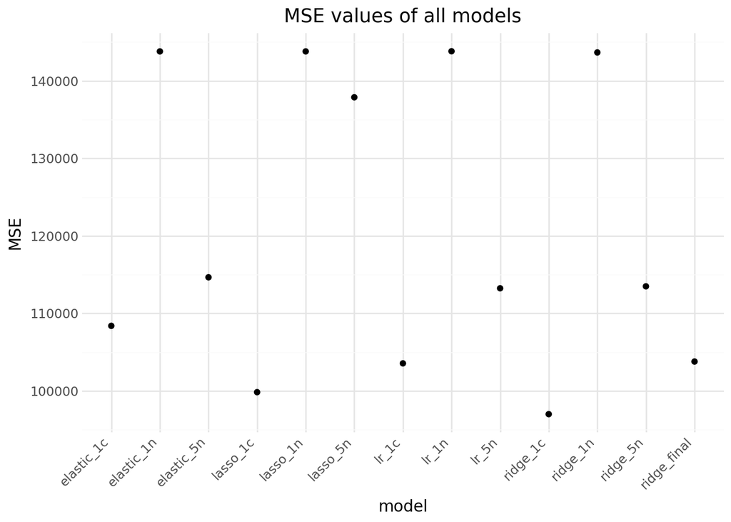

```python
# prepare data
new_row = pd.DataFrame([{"model": "ridge_final", "MSE": ridge_final_score}])
graph_df = pd.concat([MSE_compare_df, new_row])

# graph
(ggplot(graph_df,
        aes(x = "model",
            y = "MSE"))
+ geom_point()
+ labs(title = "MSE values of all models")
+ theme_minimal()
+ theme(axis_text_x=element_text(angle=45, hjust=1))
)
```

This graph shows that the final Ridge Regression model has a lower MSE value, though not the lowest out of all models generated.